# PAC 1

## Hores de feina

Podem veure que hi ha valors negatius en les hores de feina. Evidentment, això no és possible. No es poden fer un número negatiu de hores. Els valors semblen molt raonables, amb el signe equivocat.

```r
satisfaccioLaboral$work_hours[satisfaccioLaboral$work_hours <= 0]
```

```
##  [1] -31.00004 -37.60014 -39.60019 -41.30002 -41.90006 -39.70012 -36.40013
##  [8] -38.10003 -35.70020 -37.40001 -34.20018 -41.50005 -37.10011 -38.00019
## [15] -36.10003 -39.50010 -41.00014 -37.10006 -36.00019 -39.30019 -36.70007
## [22] -42.00016 -35.50011 -36.80002 -42.20018 -41.00007 -42.60010 -35.00017
## [29] -38.10004 -41.20006 -40.80003 -39.20011 -41.30000 -38.60014 -42.80008
## [36] -42.30006 -33.40013 -41.10010 -43.60007 -33.90006 -34.10013 -34.70000
## [43] -39.20006 -39.00018 -34.20016 -39.30011 -35.30020 -40.80019 -39.80015
## [50] -34.40015 -38.70017 -40.70004 -39.50019 -38.40014 -42.90009 -34.80007
## [57] -38.50000 -36.50009 -30.00012 -30.80002 -37.50003 -38.10009 -35.50011
## [64] -26.20016 -40.30012 -39.50014 -37.30002 -43.80012 -42.40018 -37.70009
## [71] -40.30012 -36.60017 -34.70001 -37.00001 -43.00007 -39.70018 -39.20020
## [78] -35.20009 -33.30013 -43.10018 -37.30006 -28.40006 -31.30015 -37.10008
## [85] -38.80008 -39.10001 -38.40004 -38.30013 -35.50009 -37.60005 -37.30012
## [92] -39.50007 -36.40001 -42.10007 -44.70013 -36.30003
```

Podem pensar que es un error d’introducció de dades i que el signe és erroni. Canviem el signe multiplicant per -1.

```r
satisfaccioLaboral$work_hours <- -1 *
  satisfaccioLaboral$work_hours[satisfaccioLaboral$work_hours <= 0]
```

## Resum de les variables

Convertim les variables que encara no estan en el tipus correcte.

```r
satisfaccioLaboral$sick_leave_b <- as.logical(satisfaccioLaboral$sick_leave_b)
satisfaccioLaboral$educ_level <- as.ordered(satisfaccioLaboral$educ_level)
```

Podem veure que ja tenim els tipus de dades objectiu

```r
sapply(satisfaccioLaboral, class)
```

```
## $city
## [1] "factor"
##
## $sex
## [1] "factor"
##
## $educ_level
## [1] "ordered" "factor"
##
## $job_type
## [1] "factor"
##
## $happiness
## [1] "numeric"
##
## $age
## [1] "integer"
##
## $seniority
## [1] "integer"
##
## $sick_leave
## [1] "integer"
##
## $sick_leave_b
## [1] "logical"
##
## $work_hours
## [1] "numeric"
##
## $Cho_initial
## [1] "numeric"
##
## $Cho_final
## [1] "numeric"
```

# 4. Normalitzeu / Estandaritzeu les variables quantitatives.

## Nivell de felicitat

El rati de valors és molt petit (només 12), així que podem assumir que assignar la mitja és correcte i no afectarà gaire a la mostra. Una vegada fet això, normalitzem la variable:
$$z_i = \frac{x_i - \overline{x}}{S}$$

```r
satisfaccioLaboral$happiness[is.na(satisfaccioLaboral$happiness)] <-
  mean(satisfaccioLaboral$happiness[!is.na(satisfaccioLaboral$happiness)])
satisfaccioLaboral$happinessNorm <- (satisfaccioLaboral$happiness -
  mean(satisfaccioLaboral$happiness)) / sd(satisfaccioLaboral$happiness)
summary(satisfaccioLaboral$happinessNorm)
```

```
##     Min.  1st Qu.   Median     Mean  3rd Qu.     Max.
## -2.94595 -0.70337  0.02184  0.00000  0.69870  3.05657
```

```r
sd(satisfaccioLaboral$happinessNorm)
```

```
## [1] 1
```

Com a resultat tenim una variable amb mitjana 0 i desviació típica 1.

## Altres variables

Primer estandarizem les working hours a un decimal

```r
satisfaccioLaboral$work_hours <- round(satisfaccioLaboral$work_hours, digits = 1)
```

Nomalitzem les altres variables de la mateixa forma, que no tenen valors NA.

```r
satisfaccioLaboral$ageNorm <-
  (satisfaccioLaboral$age - mean(satisfaccioLaboral$age)) /
  sd(satisfaccioLaboral$age);
satisfaccioLaboral$seniorityNorm <-
  (satisfaccioLaboral$seniority -
     mean(satisfaccioLaboral$seniority)) /
  sd(satisfaccioLaboral$seniority);
satisfaccioLaboral$sick_leaveNorm <-
  (satisfaccioLaboral$sick_leave - mean(satisfaccioLaboral$sick_leave)) /
  sd(satisfaccioLaboral$sick_leave);
satisfaccioLaboral$work_hoursNorm <-
  (satisfaccioLaboral$work_hours - mean(satisfaccioLaboral$work_hours)) /
  sd(satisfaccioLaboral$work_hours);
satisfaccioLaboral$Cho_initialNorm <-
  (satisfaccioLaboral$Cho_initial - mean(satisfaccioLaboral$Cho_initial)) /
  sd(satisfaccioLaboral$Cho_initial);
satisfaccioLaboral$Cho_finalNorm <-
  (satisfaccioLaboral$Cho_final - mean(satisfaccioLaboral$Cho_final)) /
  sd(satisfaccioLaboral$Cho_final);
```

S’han creat columnes noves amb els valors normalitzats per tal de no perdre la informació original. Crec que és millor crear columnes noves per tal de fer l’anàlisi i no deixar de tenir les columnes originals.

# 5. Normalitzeu / Estandaritzeu les variables qualitatives.

## Ciutat

Per a normalitzar, primer llevem els espais en blanc. Després passem totes les paraules a TitleCase (primera lletra en majúscula i les altres en minúscula). Finalment convertim les preposicions a minúscules (en el nostre exemple, només tenim el “de”).

```r
satisfaccioLaboral$city <- trimws(satisfaccioLaboral$city, "both");
satisfaccioLaboral$city <- tools::toTitleCase(satisfaccioLaboral$city);
satisfaccioLaboral$city <- stringr::str_replace(satisfaccioLaboral$city, 'De', 'de');
table(satisfaccioLaboral$city);
```

```
##
##              Barcelona                 Madrid Santiago de Compostela
##                    640                    640                    640
```

## Sexe

Tenim la variable en majúscules i minúscules. La transformem en majúscules, a més de llevar-li els espais en banc.

```r
satisfaccioLaboral$sex <- toupper(trimws(satisfaccioLaboral$sex, "both"));
table(satisfaccioLaboral$sex);
```

```
##
##   F   M
## 960 960
```

# 6. Reviseu possibles inconsistències entre variables: age versus seniority i número d’hores setmanals promig amb valor negatiu.

Les hores promig ja han estat modificades al punt 3 per a poder obtenir valors correctes a la normalització. Recordem que hem multiplicat per -1 els valors negatius.

```r
summary(satisfaccioLaboral$work_hours)
```

```
##    Min. 1st Qu.  Median    Mean 3rd Qu.    Max.
##   26.20   36.08   38.20   37.99   40.40   44.70
```

Per a trobar incoherències entre les variables age i seniority, primer crearem una variable amb l’edat en que la persona va començar a fer feina (age - seniority).

```r
satisfaccioLaboral$startAge <- satisfaccioLaboral$age - satisfaccioLaboral$seniority
```

I mirem quants tenien menys de 18 anys quan varen començar a treballar (en principi són dades inconsistents); en tenim 543.

```r
nrow(subset(satisfaccioLaboral, startAge < 18,))
```

```
## [1] 543
```

Assignem els valors a seniority tal que si li restem a l’edat mai sigui inferior a 18.

```r
satisfaccioLaboral$seniority[satisfaccioLaboral$startAge < 18] <-
  satisfaccioLaboral$seniority[satisfaccioLaboral$startAge < 18] -
  (18 - satisfaccioLaboral$startAge[satisfaccioLaboral$startAge < 18])
```

Tornem a calcular la variable startAge com age - seniority i validem que ja no hi ha cap valor inconsistent:

```r
satisfaccioLaboral$startAge <- satisfaccioLaboral$age - satisfaccioLaboral$seniority
summary(satisfaccioLaboral$startAge)
```

```
##    Min. 1st Qu.  Median    Mean 3rd Qu.    Max.
##    18.0    18.0    20.0    21.3    24.0    35.0
```

```r
summary(satisfaccioLaboral$startAge)
```

```
##    Min. 1st Qu.  Median    Mean 3rd Qu.    Max.
##    18.0    18.0    20.0    21.3    24.0    35.0
```

Recalculem la variable normalitzada de seniority:

```r
satisfaccioLaboral$seniorityNorm <-
  (satisfaccioLaboral$seniority - mean(satisfaccioLaboral$seniority)) /
  sd(satisfaccioLaboral$seniority)
summary(satisfaccioLaboral$seniorityNorm)
```

```
##    Min. 1st Qu.  Median    Mean 3rd Qu.    Max.
## -2.7788 -0.5882  0.1420  0.0000  0.7262  2.3327
```

# 7. Busqueu valors atípics en les variables quantitatives.

## i. Presenteu un boxplot per cada variable quantitativa.

## Edat

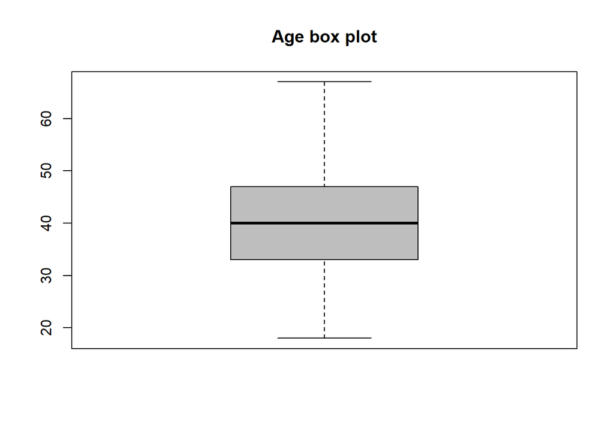

```r
boxplot(satisfaccioLaboral$age,main="Age box plot", col="gray")
```

No hi ha valors outliers:

```r
boxplot.stats(satisfaccioLaboral$age)$out
```

```
## integer(0)
```

Ens assegurem calculant el rang d’edat en base al rang interquantil:

```r
quantile(satisfaccioLaboral$age, 0.25) -
  (IQR(satisfaccioLaboral$age) * 1.5)
```

```
## 25%
##  12
```

```r
quantile(satisfaccioLaboral$age, 0.75) +
  (IQR(satisfaccioLaboral$age) * 1.5)
```

```
## 75%
##  68
```

Efectivament, no hi ha ningú amb menys de 12 anys ni amb més de 68.

## Anys d’experiència

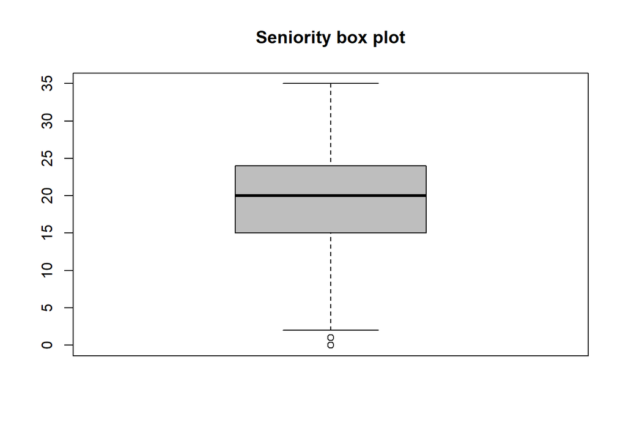

```r
boxplot(satisfaccioLaboral$seniority,main="Seniority box plot", col="gray")
```

```r
boxplot.stats(satisfaccioLaboral$seniority)$out
```

```
##  [1] 0 0 0 0 0 0 0 0 1 0 0 0 0 0 0 0 0 0 0 0 0 0 0 0 0 0 0 0 0 1 0 0 0 0 0
## [36] 0 0 0 0 0 0 0 1 0 0 0 0
```

Aquí sí hi ha valors outliers, els que tenen 0 o 1 any d’experiència

## Nivell de felicitat

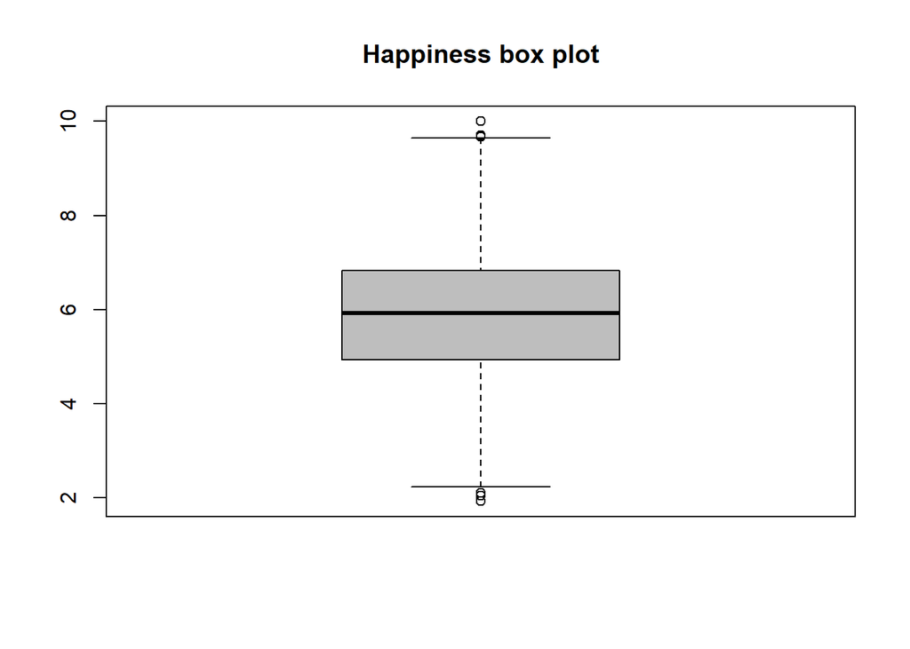

```r
boxplot(satisfaccioLaboral$happiness,main="Happiness box plot", col="gray")
```

```r
boxplot.stats(satisfaccioLaboral$happiness)$out
```

```
## [1] 10.00  2.10  9.70  9.68  2.05  2.05  1.93  1.93
```

Aquí tenim valors outliers tant per abaix com per adalt.

## Dies de baixa

Aquí tenim molt de valors outliers; la gran majoria de valors són 0. Això provoca que tant el primer quantil com el tercer siguin 0. Això fa que qualsevol valor diferent de 0 sigui outlier.

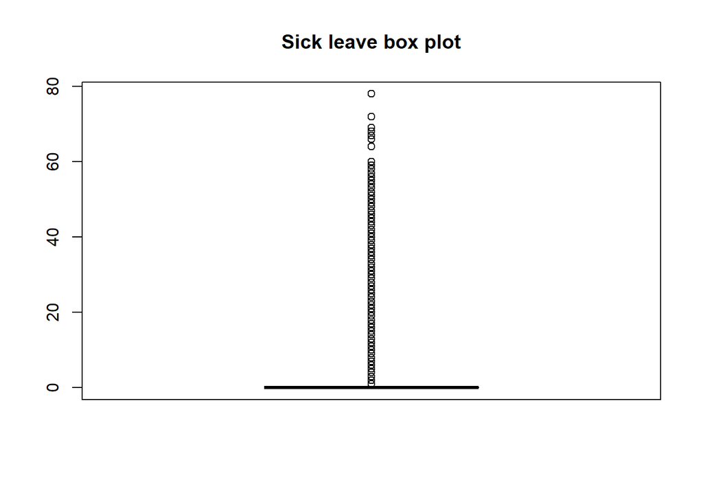

```r
boxplot(satisfaccioLaboral$sick_leave,main="Sick leave box plot", col="gray")
```

```r
boxplot.stats(satisfaccioLaboral$sick_leave)$out
```

```
##   [1]  6 24 36  1 23  9 53 42 14 27 50 26  3 18 16 10 48 32 51 35 40 28 32
##  [24] 38 51 20 32 41 41 13 38 39 23 36 13 31 30 32 46  8 10 38 56 19 46 33
##  [47] 35  6  9 24  9 11 52 20 15 30 22 22 43  4 34 29 67 40 21  4 26 49  9
##  [70] 16 29 37 27 39 21 31 53 11 22 26 36 14 41 43 12 15  3 12 22 25 53 26
##  [93] 15 36 20 22 29 69 40 34 22 33 14 55 57 20  6 16 40 34 15 47  8 17 40
## [116] 60 68 27 21 45  5 57 34 18 33 11  8  6 20 26 39 20 25 27  1 51 31  3
## [139] 14  7 13 59  7 11 16 29  8 24 57 48 53 27 20 26 27 12 29 33 39 32 45
## [162] 21 56  1 20 41 18 33 23 20 18 41 51 18 57 40 27 12 15  6 22 16 28 17
## [185] 23 53 12  3 39  7 32 30 38 17 14 72 26 28 15 45  6 37 49 22  9 16 21
## [208] 39 19  1 19 31  5 40 20 18 11 44  8 14 46 16 24 42 30 46  1 17 19 24
## [231] 15 25 35 45  7  9 43  8 51 64 21 26 21 48 29 12 19 18 49 42 30 33 24
## [254]  8 14 14  7 24 31 33 17 54 56 32  4  5 34 11 34 27 56 38 11 38 29  7
## [277] 22 30 15  2  4 21 39 19 20 51 31 22 15 17 11 11 28 40 11 35 56 15 44
## [300] 29 29 38 56 29 42 34 11 15 31 21 17 43 23 39  6 40 57  7 33 23  3 24
## [323] 35  6  5 11  6  5 45 40 52 25 25 20 38 66 24 42 39 17 40 19 27 18 45
## [346] 23  3 34 46 15 23 27 52 22 22  8 39 16 17 12 20 16 13 23 25 41  4 38
## [369] 18  7 52 21 38 49 35 22 78 29 12  5 37 22 12  6 42 28 34 11 21 14 14
## [392] 32 56 10 60 27 11 30 41 22  3 45  2 35 16 45 47 34 27 18 31 46 42 11
## [415] 40  4 29 28 13 17 29 50  6 47 23  3 11 22 36 35 30 16 29 28 42 32  8
## [438] 21 58 19 31 29 23 37 34 16 10 32 26 47 15 35 22 14 14 17 27  9 23 26
## [461] 29 33 57 18 20 31 39 21 37 25 45 18 47
```

## Hores de feina

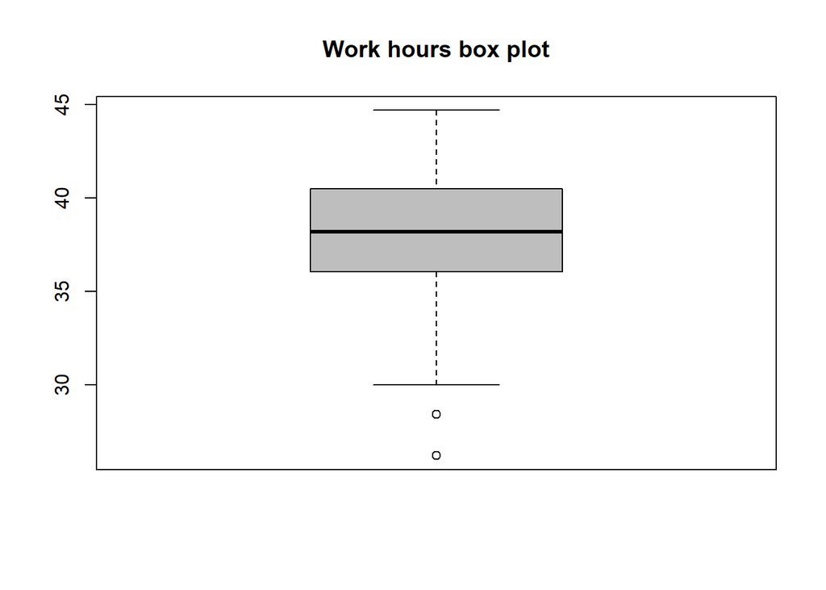

```r
boxplot(satisfaccioLaboral$work_hours,main="Work hours box plot", col="gray")
```

```r
boxplot.stats(satisfaccioLaboral$work_hours)$out
```

```
##  [1] 26.2 28.4 26.2 28.4 26.2 28.4 26.2 28.4 26.2 28.4 26.2 28.4 26.2 28.4
## [15] 26.2 28.4 26.2 28.4 26.2 28.4 26.2 28.4 26.2 28.4 26.2 28.4 26.2 28.4
## [29] 26.2 28.4 26.2 28.4 26.2 28.4 26.2 28.4 26.2 28.4 26.2 28.4
```

Tenim 40 valors fora dels límits (tots per abaix)

```r
knitr::kable(head(satisfaccioLaboral), format = "latex")
```

[output not shown]

Els resultats són els mateixos si treballem amb la variable normalitzada

## Colesterol penúltima medició

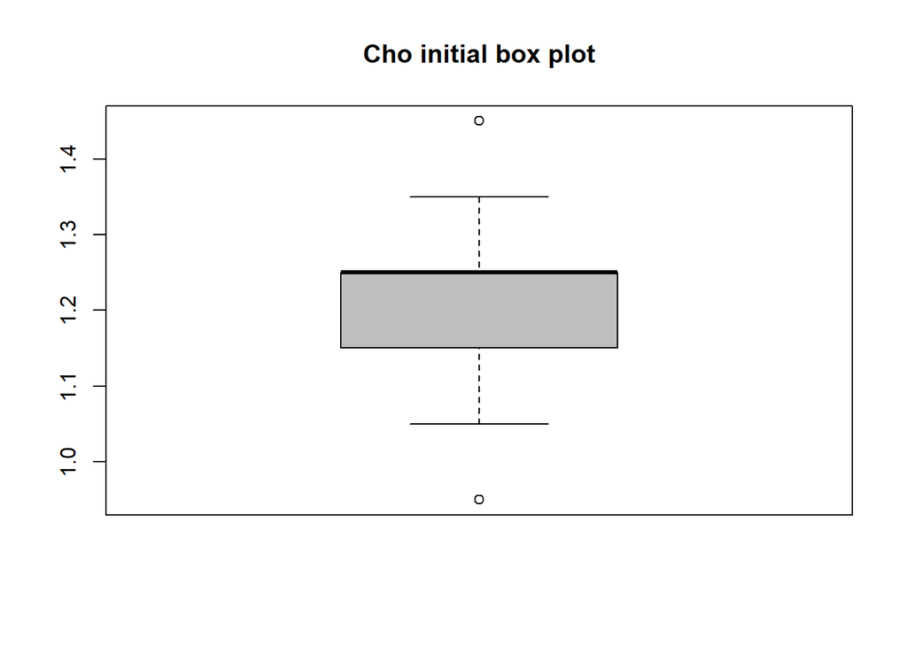

```r
boxplot(satisfaccioLaboral$Cho_initial,main="Cho initial box plot", col="gray")
```

```r
boxplot.stats(satisfaccioLaboral$Cho_initial)$out
```

```
## [1] 1.45 1.45 0.95 1.45
```

Aquí també tenim valors outliers tant per adalt com per abaix

## Colesterol última medició

Aquí no tenim valors outliers, perquè el rang interquantílic és més ampli. És a dir: els valors són més lluny de la mitja. Això fa que valors que amb la gràfica anterior s’haguessin considerat outliers, aquí són “normals”.

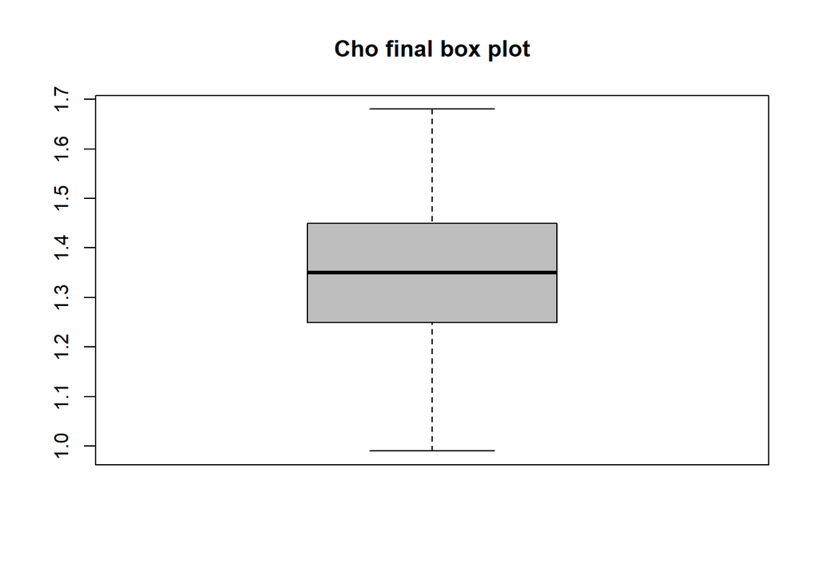

```r
boxplot(satisfaccioLaboral$Cho_final,main="Cho final box plot", col="gray")
```

```r
boxplot.stats(satisfaccioLaboral$Cho_final)$out
```

```
## numeric(0)
```

Els resultats són els mateixos si treballem amb la variable normalitzada

# 8. Valors perduts

## i.Busqueu quines variables i quins registres tenen valors perduts.

L’única variable amb valors perduts és happiness (12 NA). Com abans he assignat el valor de la mitja per a fer l’anàlisi, torn enrere el canvi:

```r
satisfaccioLaboralAux <-
  read.table("D:/Users/cagarcia/uoc/M2.954 - Estadística avançada/PAC1/rawData.csv",
             header=TRUE, sep=",", na.strings="NA", dec=".", strip.white=TRUE,
             blank.lines.skip = TRUE)
satisfaccioLaboral$happiness <- satisfaccioLaboralAux$happiness
satisfaccioLaboral$happiness <- gsub(",", ".", satisfaccioLaboral$happiness);
satisfaccioLaboral$happiness <- as.numeric(satisfaccioLaboral$happiness);
head(satisfaccioLaboral$happiness)
```

```
## [1] 7.23 5.93   NA 6.33 8.93 7.23
```

## ii. Imputeu els valors a partir dels k-veïns més propers usant la distància de Gower amb la informació de totes les variables.

Prendrem com a nombre K = 5, que és el valor per defecte. Considerem totes les variables, no s’exclou cap columna. Per veure el resultat, guardem els valors a la variable happinessComplete. Així podrem comprovar els valors assignats:

```r
satisfaccioLaboral.complet <- VIM::kNN(satisfaccioLaboral);
satisfaccioLaboral$happinessComplete <- satisfaccioLaboral.complet$happiness;
```

Comprovem els valors assignats:

```r
satisfaccioLaboral$happinessComplete[is.na(satisfaccioLaboral$happiness)]
```

```
##  [1] 5.68 5.35 6.61 5.03 5.38 6.23 6.93 6.03 6.10 6.23 6.33 4.75
```

Ara que sabem que està bé, li assignem a la variable:

```r
satisfaccioLaboral$happiness <- satisfaccioLaboral$happinessComplete
```

# 9. Realitzeu un breu estudi descriptiu de les dades un cop depurades.

Mostrem el summary de totes les variables una vegada depurades. De les que no es veuen les dades, mostrem la distribució mitjançant l’operació table.

```r
sapply(satisfaccioLaboral[c("happiness", "educ_level",
                            "job_type", "age", "seniority", "sick_leave",
                            "sick_leave_b", "work_hours", "Cho_initial",
                            "Cho_final")], summary)
```

```
## $happiness
##    Min. 1st Qu.  Median    Mean 3rd Qu.    Max.
##   1.930   4.930   5.930   5.891   6.830  10.000
##
## $educ_level
##   N   P   S   U
## 480 480 480 480
##
## $job_type
##   C  PC
## 960 960
##
## $age
##    Min. 1st Qu.  Median    Mean 3rd Qu.    Max.
##   18.00   33.00   40.00   40.33   47.00   67.00
##
## $seniority
##    Min. 1st Qu.  Median    Mean 3rd Qu.    Max.
##    0.00   15.00   20.00   19.03   24.00   35.00
##
## $sick_leave
##    Min. 1st Qu.  Median    Mean 3rd Qu.    Max.
##   0.000   0.000   0.000   6.667   0.000  78.000
##
## $sick_leave_b
##    Mode   FALSE    TRUE
## logical    1447     473
##
## $work_hours
##    Min. 1st Qu.  Median    Mean 3rd Qu.    Max.
##   26.20   36.08   38.20   37.99   40.40   44.70
##
## $Cho_initial
##    Min. 1st Qu.  Median    Mean 3rd Qu.    Max.
##    0.95    1.15    1.25    1.20    1.25    1.45
##
## $Cho_final
##    Min. 1st Qu.  Median    Mean 3rd Qu.    Max.
##   0.990   1.250   1.350   1.351   1.450   1.680
```

```r
table(satisfaccioLaboral$city)
```

```
##
##              Barcelona                 Madrid Santiago de Compostela
##                    640                    640                    640
```

```r
table(satisfaccioLaboral$sex)
```

```
##
##   F   M
## 960 960
```

# 10. Finalment, emmagatzemeu les dades en un arxiu de dades corregit.

Desem els resultats al fitxer rawDataNet.csv

```r
write.table(satisfaccioLaboral[c("city", "sex", "happiness", "educ_level",
  "job_type", "age", "seniority", "sick_leave",
  "sick_leave_b", "work_hours", "Cho_initial",
  "Cho_final")],
  file = "D:/Users/cagarcia/uoc/M2.954 - Estadística avançada/PAC1/rawDataNet.csv",
  append = FALSE, sep = ";", row.names = FALSE)
```